# **Computer Assignment 1 - Task 1**

**Collaborators:**

Mehrad Liviyan - 810101501  
Shayan Saeedi - 810101442

## Install Libraries

```python
!pip install opencv-python
```

## Load Image

```
Image loaded successfully
```

[figure not shown]

```
Data type: uint8
Shape: (600, 800, 3)
Number of color channels: 3
```

```python
import cv2
from matplotlib import pyplot as plt
import numpy as np

image = cv2.imread("/content/drive/MyDrive/Computer Vision - F04/CA1/Description/Pic.jpg")
if image is None:
    print("Error: Image not found or path is incorrect")
else:
    print("Image loaded successfully")
    plt.imshow(image)
    plt.axis("off")
    plt.show()
    print("Data type:", image.dtype)
    print("Shape:", image.shape)
    if len(image.shape) == 3:
        print("Number of color channels:", image.shape[2])
    else:
        print("Grayscale image (1 channel)")
```

## Convert to RGB, Grayscale and Binary

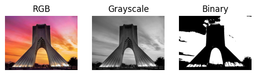

```
RGB:
Data type: uint8
Shape: (600, 800, 3)

Grayscale:
Data type: uint8
Shape: (600, 800)
some pixels: [89 89 89 89 90 90 90 90 90 90]

Binary:
Data type: uint8
Shape: (600, 800)
some pixels: [0 0 0 0 0 0 0 0 0 0]
```

```python
rgb_image = cv2.cvtColor(image, cv2.COLOR_BGR2RGB)
gray_image = cv2.cvtColor(image, cv2.COLOR_BGR2GRAY)
_, binary_image = cv2.threshold(gray_image, 127, 255, cv2.THRESH_BINARY)


plt.subplot(1, 3, 1)
plt.title("RGB")
plt.imshow(rgb_image)
plt.axis("off")

plt.subplot(1, 3, 2)
plt.title("Grayscale")
plt.imshow(gray_image, cmap="gray")
plt.axis("off")

plt.subplot(1, 3, 3)
plt.title("Binary")
plt.imshow(binary_image, cmap="gray")
plt.axis("off")

plt.show()


print("\nRGB:")
print("Data type:", rgb_image.dtype)
print("Shape:", rgb_image.shape)

print("\nGrayscale:")
print("Data type:", gray_image.dtype)
print("Shape:", gray_image.shape)
print("some pixels:", gray_image[47][26:36])

print("\nBinary:")
print("Data type:", binary_image.dtype)
print("Shape:", binary_image.shape)
print("some pixels:", binary_image[47][26:36])
```

- RGB: سه بعد داره که هر کدوم به ترتیب نشان دهنده قرمز و سبز و آبی بودن آن پیکسل هست.
- Grayscale:

هر پیکسل یک بعد دارد و یک عدد بین 0 تا 255 است و هر چه به 0 نزدیک تر شود تیره تر ( مشکی تر ) است.

## HSV

```
(np.float64(-0.5), np.float64(799.5), np.float64(599.5), np.float64(-0.5))
```

[figure not shown]

```python
hsv_image = cv2.cvtColor(image, cv2.COLOR_BGR2HSV)

plt.subplot(2, 2, 3)
plt.imshow(hsv_image)
plt.title("HSV Image")
plt.axis("off")
```

HSV مخفف این هاست:

- H = Hue → نوع رنگ (مثل قرمز، آبی، زرد)
- S = Saturation → میزان خلوص یا شدت رنگ
- V = Value → میزان روشن یا تیره بودن رنگ

HSV یک روش دیگر برای نمایش رنگ‌ها در کنار RGB است.

در مدل RGB، روشنایی و رنگ با هم ترکیب شده‌اند، بنابراین جدا کردن یک رنگ خاص در شرایط نوری متفاوت سخت است.

اما در HSV، روشنایی (Value) از رنگ (Hue) جدا شده است، بنابراین می‌توانید به‌راحتی:

- یک رنگ مشخص را تشخیص دهید (مثل پیدا کردن اجسام قرمز)
- روشنایی و کنتراست را تنظیم کنید
- رنگ‌ها را در شرایط نوری مختلف به‌طور دقیق‌تر فیلتر کنید

مفهوم کانال‌ها در HSV:

| کانال | معنی | بازه |
| --- | --- | --- |
| **H (Hue)** | نوع رنگ | در OpenCV از **0 تا 179** (نه 360) |
| **S (Saturation)** | شدت یا اشباع رنگ | **0 تا 255** |
| **V (Value)** | روشنایی | **0 تا 255** |

خلاصه:

| فضای رنگ | توضیح | کاربرد معمول |
| --- | --- | --- |
| **BGR/RGB** | کانال‌های آبی، سبز و قرمز | نمایش تصاویر |
| **Grayscale** | فقط روشنایی | تشخیص لبه، آستانه‌گذاری (Thresholding) |
| **HSV** | فام، اشباع، روشنایی | تشخیص رنگ، فیلتر کردن رنگ، تنظیم روشنایی |

## split RGB and HSV

[figure not shown]

```python
r, g, b = cv2.split(rgb_image)
plt.figure(figsize=(10, 4))

plt.subplot(1, 3, 1)
plt.title("R")
plt.imshow(r, cmap="gray")
plt.axis("off")

plt.subplot(1, 3, 2)
plt.title("G")
plt.imshow(g, cmap="gray")
plt.axis("off")

plt.subplot(1, 3, 3)
plt.title("B")
plt.imshow(b, cmap="gray")
plt.axis("off")

plt.show()
```

[figure not shown]

```python
h, s, v = cv2.split(hsv_image)
plt.figure(figsize=(10, 4))

plt.subplot(1, 3, 1)
plt.title("Hue")
plt.imshow(h, cmap="gray")
plt.axis("off")

plt.subplot(1, 3, 2)
plt.title("Saturation")
plt.imshow(s, cmap="gray")
plt.axis("off")

plt.subplot(1, 3, 3)
plt.title("Value")
plt.imshow(v, cmap="gray")
plt.axis("off")

plt.show()
```

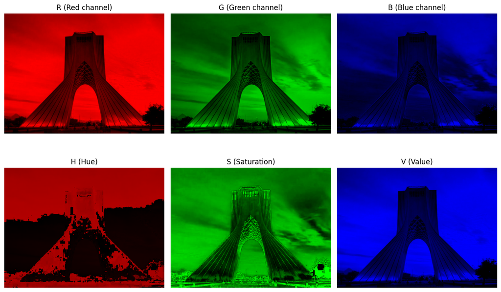

```python
r_img = cv2.merge([r, np.zeros_like(g), np.zeros_like(b)])
g_img = cv2.merge([np.zeros_like(r), g, np.zeros_like(b)])
b_img = cv2.merge([np.zeros_like(r), np.zeros_like(g), b])


h_img = cv2.merge([h, np.zeros_like(s), np.zeros_like(v)])
s_img = cv2.merge([np.zeros_like(h), s, np.zeros_like(v)])
v_img = cv2.merge([np.zeros_like(h), np.zeros_like(s), v])

plt.figure(figsize=(12, 8))

# --- RGB ---
plt.subplot(2, 3, 1)
plt.imshow(r_img)
plt.title("R (Red channel)")
plt.axis("off")

plt.subplot(2, 3, 2)
plt.imshow(g_img)
plt.title("G (Green channel)")
plt.axis("off")

plt.subplot(2, 3, 3)
plt.imshow(b_img)
plt.title("B (Blue channel)")
plt.axis("off")

# --- HSV ---
plt.subplot(2, 3, 4)
plt.imshow(h_img)
plt.title("H (Hue)")
plt.axis("off")

plt.subplot(2, 3, 5)
plt.imshow(s_img)
plt.title("S (Saturation)")
plt.axis("off")

plt.subplot(2, 3, 6)
plt.imshow(v_img)
plt.title("V (Value)")
plt.axis("off")

plt.tight_layout()
plt.show()
```

همانطور که واضح است RGB خیلی مناسب نمایش تصاویر است ولی HSV مناسب تشخیص رنگ، فیلتر کردن رنگ، تنظیم روشنایی است.

توضیح:

| فضای رنگ | کانال | معنی | بازه |
| --- | --- | --- | --- |
| **RGB** | **R** | شدت رنگ قرمز | ۰ تا ۲۵۵ |
|  | **G** | شدت رنگ سبز | ۰ تا ۲۵۵ |
|  | **B** | شدت رنگ آبی | ۰ تا ۲۵۵ |
| **HSV** | **H** | فام (نوع رنگ) | ۰ تا ۱۷۹ (در OpenCV) |
|  | **S** | اشباع رنگ (شدت رنگ) | ۰ تا ۲۵۵ |
|  | **V** | ارزش نوری / روشنایی | ۰ تا ۲۵۵ |

## Contrast

کنتراست به اختلاف بین روشن‌ترین و تیره‌ترین قسمت‌های یک تصویر گفته می‌شود. کنتراست بالا یعنی تفاوت واضح بین بخش‌های روشن و تیره تصویر وجود دارد. کنتراست پایین یعنی تصویر یکنواخت‌تر و بدون اختلاف زیاد در روشنایی است.

- کنتراست بالا: نواحی بسیار روشن و بسیار تیره با مرزهای مشخص (وضوح بیشتر).
- کنتراست پایین: تصویر خاکستری و کدر با روشنایی یکنواخت (وضوح کمتر).

یکی از روش‌های رایج برای محاسبه کنتراست، استفاده از انحراف معیار مقدار شدت پیکسل‌ها است. هر چه انحراف معیار بیشتر باشد، اختلاف بین نواحی روشن و تیره بیشتر است، پس کنتراست بالاتر است.

فرمول:

$$[ Contrast = \frac{\sigma}{\mu} ]$$

که در آن:

- ( $\sigma$ ) = انحراف معیار شدت پیکسل‌ها (میزان پراکندگی مقدار روشنایی)
- ( $\mu$ ) = میانگین شدت پیکسل‌ها (روشنایی متوسط تصویر)

توضیح:

- میانگین → روشنایی کلی تصویر را نشان می‌دهد.
- انحراف معیار → اختلاف بین مقادیر روشنایی را نشان می‌دهد.
- کنتراست → نسبت این دو مقدار است؛ هرچه نسبت بزرگ‌تر باشد، کنتراست بیشتر است.

می‌توانیم با تغییر مقیاس مقدار پیکسل‌ها (Contrast Stretching) کنتراست را تنظیم کنیم.

فرمول کلی:

$$[ new_image = \alpha \times original_image + \beta ]$$

- ( $\alpha$ ) = ضریب کنتراست
  - بیشتر از 1 برای افزایش کنتراست
  - بین 0 و 1 برای کاهش کنتراست
- ( $\beta$ ) = ضریب روشنایی (معمولاً مقدار آن 0 است)

مثال:

- افزایش کنتراست → ( $\alpha$ = 2.0 )
- کاهش کنتراست → ( $\alpha$ = 0.5 )

در OpenCV از تابع زیر استفاده می‌شود:

```
cv2.convertScaleAbs()
```

- تصویر با کنتراست افزایش‌یافته → رنگ‌ها زنده‌تر و مرز بین بخش‌های تیره و روشن مشخص‌تر.
- تصویر با کنتراست کاهش‌یافته → رنگ‌ها ملایم‌تر و مرزها کمتر مشخص.

```python
mean = np.mean(image)
std_dev = np.std(image)

# Calculate contrast
contrast = std_dev / mean if mean != 0 else 0

print(f"Mean Intensity: {mean}")
print(f"Standard Deviation: {std_dev}")
print(f"Contrast: {contrast}")
```

```
Mean Intensity: 122.65668125
Standard Deviation: 72.23226597724953
Contrast: 0.5888979323517244
```

[figure not shown]

```python
alpha = 2.0
increased_contrast = cv2.convertScaleAbs(gray_image, alpha=alpha, beta=0)

alpha = 0.5
decreased_contrast = cv2.convertScaleAbs(gray_image, alpha=alpha, beta=0)

plt.figure(figsize=(12, 6))

plt.subplot(1, 3, 1)
plt.imshow(gray_image, cmap="gray")
plt.title("Original Image")
plt.axis("off")

plt.subplot(1, 3, 2)
plt.imshow(increased_contrast, cmap="gray")
plt.title("Increased Contrast")
plt.axis("off")

plt.subplot(1, 3, 3)
plt.imshow(decreased_contrast, cmap="gray")
plt.title("Decreased Contrast")
plt.axis("off")

plt.tight_layout()
plt.show()
```

## local contrast

یک روش دیگر برای اندازه‌گیری کنتراست محلی این است که اختلاف شدت دو پیکسل مجاور را محاسبه کنیم.

فرمول برای هر پیکسل:

- جهت افقی:

$$ [ Difference = |Pixel(i, j) - Pixel(i+1, j)| ] $$

- جهت عمودی:

$$[ Difference = |Pixel(i, j) - Pixel(i, j+1)| ]$$

در نهایت بیشترین اختلاف را استخراج می‌کنیم.

- نقشهٔ اختلاف پیکسل نشان‌دهنده مناطق دارای تغییر شدت زیاد است (مثل لبه‌ها)
- در این نقشه، مناطق با اختلاف بالا معمولاً با رنگ‌های گرم (قرمز، زرد) مشخص می‌شوند.

کاربردها:

تشخیص لبه‌ها: اختلاف زیاد معمولاً روی مرزهای اشیا دیده می‌شود.

تحلیل بافت: در نواحی دارای بافت زیاد، اختلاف شدت پیکسل‌ها بالا است.

```
Maximum pixel difference between neighboring pixels: 196
```

[figure not shown]

```python
height, width = gray_image.shape

max_diff = 0

for i in range(height - 1):
    for j in range(width - 1):
        diff_h = abs(int(gray_image[i, j]) - int(gray_image[i, j + 1]))

        diff_v = abs(int(gray_image[i, j]) - int(gray_image[i + 1, j]))

        max_diff = max(max_diff, diff_h, diff_v)

print(f"Maximum pixel difference between neighboring pixels: {max_diff}")


diff_map = np.zeros_like(gray_image, dtype=np.uint8)

for i in range(height - 1):
    for j in range(width - 1):
        diff_h = abs(int(gray_image[i, j]) - int(gray_image[i, j + 1]))
        diff_v = abs(int(gray_image[i, j]) - int(gray_image[i + 1, j]))
        diff_map[i, j] = max(diff_h, diff_v)

plt.imshow(diff_map, cmap="hot")
plt.title("Difference Map")
plt.axis("off")
plt.show()
```

## Histogram

هیستوگرام تصویر نموداری است که نشان می‌دهد شدت روشنایی پیکسل‌ها در تصویر چگونه توزیع شده است.

برای تصویر سطح خاکستری (Grayscale):

هیستوگرام نشان می‌دهد چه تعداد پیکسل هر مقدار شدت روشنایی را دارند (از 0 تا 255).

- 0 → سیاه
- 255 → سفید
- مقادیر بین 0 و 255 → درجات مختلف خاکستری

برای تصویر رنگی (RGB):

می‌توان سه هیستوگرام رسم کرد , یکی برای کانال قرمز (R)، یکی برای سبز (G) و یکی برای آبی (B).

هیستوگرام کمک می‌کند کنتراست، روشنایی و نوردهی تصویر را تحلیل کنیم.

| شکل هیستوگرام | معنی |
| --- | --- |
| قلهٔ بلند و باریک در وسط | کنتراست کم |
| پخش شده در کل بازه | کنتراست بالا |
| شیب به سمت چپ | تصویر تیره |
| شیب به سمت راست | تصویر روشن |

- اگر هیستوگرام در سمت چپ متمرکز باشد → تصویر تیره است.
- اگر هیستوگرام در سمت راست متمرکز باشد → تصویر روشن است.
- اگر هیستوگرام در کل بازه پخش شده باشد → کنتراست بالا.
- اگر هیستوگرام باریک و وسط باشد → کنتراست پایین.

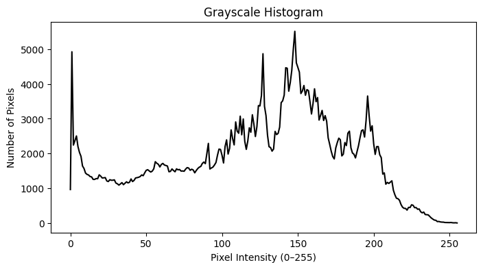

```python
hist = cv2.calcHist([gray_image], [0], None, [256], [0, 256])

plt.figure(figsize=(8, 4))
plt.plot(hist, color='black')
plt.title("Grayscale Histogram")
plt.xlabel("Pixel Intensity (0–255)")
plt.ylabel("Number of Pixels")
plt.show()
```

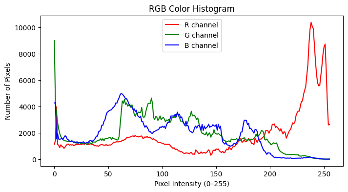

```python
colors = ('r', 'g', 'b')
plt.figure(figsize=(8, 4))

for i, color in enumerate(colors):
    hist = cv2.calcHist([rgb_image], [i], None, [256], [0, 256])
    plt.plot(hist, color=color, label=f"{color.upper()} channel")

plt.title("RGB Color Histogram")
plt.xlabel("Pixel Intensity (0–255)")
plt.ylabel("Number of Pixels")
plt.legend()
plt.show()
```

## Histogram Equalization

همسان‌سازی هیستوگرام (Histogram Equalization) روشی است که مقادیر شدت روشنایی پیکسل‌ها را طوری بازتوزیع می‌کند که در کل بازهٔ 255–0 به‌طور یکنواخت‌تری پخش شوند.

این کار کنتراست کلی تصویر را افزایش می‌دهد — مخصوصاً وقتی تصویر نور نامناسب داشته باشد یا پیکسل‌ها در یک محدوده‌ی روشنایی خاص تجمع کرده باشند.

- نواحی تیره → روشن‌تر می‌شوند.
- نواحی روشن → کمی تیره‌تر می‌شوند.
- هیستوگرام → یکنواخت‌تر و مسطح‌تر می‌شود.

مراحل الگوریتم به این صورت است:

1. ابتدا هیستوگرام تصویر را محاسبه می‌کنیم، یعنی تعداد پیکسل‌هایی که در هر مقدار روشنایی (۰ تا ۲۵۵) وجود دارند را می‌شماریم.
2. سپس تابع توزیع تجمعی یا CDF (Cumulative Distribution Function) را از هیستوگرام به‌دست می‌آوریم:

$$[ CDF(i) = \sum_{j=0}^{i} Histogram(j) ]$$

3. CDF به محدوده‌ی شدت روشنایی نرمال‌سازی می‌شود. این کار با استفاده از فرمول زیر انجام می‌شود:

$$[ new_pixel(i) = \frac{CDF(i) - CDF_{min}}{(TotalPixels - CDF_{min})} \times (L - 1) ]$$

که در آن:

- ( L ) تعداد سطوح شدت ممکن است (برای تصویر 8 بیتی: ( L = 256 ))
- ( CDF_{min} ) کوچک‌ترین مقدار غیر صفر CDF
- ( TotalPixels ) تعداد کل پیکسل‌های تصویر
4. در نهایت، هر پیکسل در تصویر ورودی با مقدار جدید ( new_pixel(i) ) جایگزین می‌شود.

[figure not shown]

```python
equalized = cv2.equalizeHist(gray_image)
plt.figure(figsize=(12, 6))

plt.subplot(2, 2, 1)
plt.imshow(gray_image, cmap='gray')
plt.title("Original Image")
plt.axis("off")

plt.subplot(2, 2, 2)
plt.imshow(equalized, cmap='gray')
plt.title("Equalized Image")
plt.axis("off")

plt.subplot(2, 2, 3)
plt.hist(gray_image.ravel(), 256, [0,256])
plt.title("Original Histogram")

plt.subplot(2, 2, 4)
plt.hist(equalized.ravel(), 256, [0,256])
plt.title("Equalized Histogram")

plt.tight_layout()
plt.show()
```

## Histogram Stretching

کشش هیستوگرام (Histogram Stretching) یک روش خطی برای افزایش کنتراست است که بازه‌ی شدت روشنایی را طوری می‌کشد که تیره‌ترین پیکسل برابر (سیاه) و روشن‌ترین پیکسل برابر ۲۵۵ (سفید) شود.

بر خلاف همسان‌سازی، این روش روشنایی نسبی پیکسل‌ها را حفظ می‌کند — هیستوگرام را بازتوزیع نمی‌کند، فقط آن را می‌کشد.

اگر تصویری فقط بخشی از بازهٔ روشنایی را استفاده کند (مثلاً 50 تا 180)، کشش پیکسل‌ها را به این شکل نگاشت می‌کند:

- **50 → 0**
- **180 → 255**

این روش ساده‌تر است و نتیجه‌ای طبیعی‌تر نسبت به همسان‌سازی تولید می‌کند.

$$[ new_pixel = \frac{(pixel - min)}{(max - min)} \times 255 ]$$

```
max value: 254
min value: 0
```

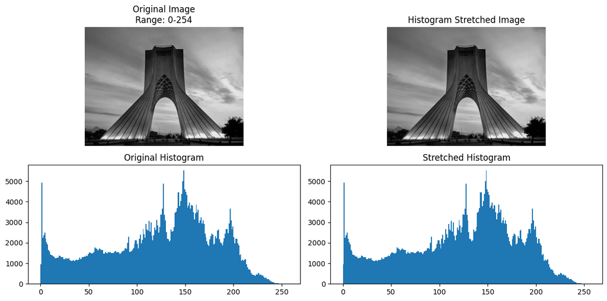

```python
min_val = np.min(gray_image)
max_val = np.max(gray_image)
print("max value:", max_val)
print("min value:", min_val)
stretched = ((gray_image - min_val) / (max_val - min_val) * 255).astype(np.uint8)
plt.figure(figsize=(12, 6))

plt.subplot(2, 2, 1)
plt.imshow(gray_image, cmap='gray')
plt.title(f"Original Image\nRange: {min_val}-{max_val}")
plt.axis("off")

plt.subplot(2, 2, 2)
plt.imshow(stretched, cmap='gray')
plt.title("Histogram Stretched Image")
plt.axis("off")

plt.subplot(2, 2, 3)
plt.hist(gray_image.ravel(), 256, [0,256])
plt.title("Original Histogram")

plt.subplot(2, 2, 4)
plt.hist(stretched.ravel(), 256, [0,256])
plt.title("Stretched Histogram")

plt.tight_layout()
plt.show()
```

## Summary Histograms

جدول خلاصه:

| روش | چه کاری انجام می‌دهد | مناسب برای | تابع |
| --- | --- | --- | --- |
| **Histogram Equalization** | بازتوزیع شدت روشنایی برای یکنواخت کردن هیستوگرام | تصاویر کم‌کنتراست سیاه‌وسفید یا رنگی | `cv2.equalizeHist()` |
| **Histogram Stretching** | مقیاس‌دهی خطی شدت روشنایی به بازهٔ کامل 255–0 | تصاویری که از کل بازهٔ روشنایی استفاده نمی‌کنند | فرمول دستی (Custom Formula) |

- **همسان‌سازی هیستوگرام:** روشنایی‌ها را بازتوزیع می‌کند → افزایش کنتراست قوی‌تر، اما ممکن است مصنوعی به نظر برسد.
- **کشش هیستوگرام:** روشنایی را مقیاس‌دهی می‌کند → افزایش طبیعی‌تر کنتراست.